# statTarget

Hemi Luan

Modified: 16 Sep 2016. Compiled: 29 Sep 2016

# 1 Background

`Quality Control (QC)` has been considered as an essential step in the metabolomics platform for high reproducibility and accuracy of data. The secondary use of the same QC samples is more and more acceptable for correcting the signal drift during the sequence of MS run order, especially benefiting to improve the quality of data in multi-block experiments of `large-scale metabolomic study`. statTarget is easy use tool to provide a graphical user interface for `quality control based signal shift correction`, integration of metabolomic data from `multi-batch experiments`, and the comprehensive statistic analysis in non-targeted or targeted metabolomics. This document is intended to guide the user to use `statTargetGUI` to perform metabolomic data analysis. Note that this document will not describe the inner workings of `statTarget algorithm`.

## 1.1 System requirements

Dependent on R (>= 3.3.0)

## 1.2 Opening the GUI

Load the package with biocLite():

```r
source("https://bioconductor.org/biocLite.R")
```

```
#> Bioconductor version 3.3 (BiocInstaller 1.22.3), ?biocLite for help
```

```r
biocLite("statTarget")
```

[output not shown]

For mac PC, the package statTargetGUI requires X11 support (XQuartz). Download it from https://www.xquartz.org.

# 2 GUI overview

An easy to use tool provide a graphical user interface (Figure 1) for quality control based signal correction, integration of metabolomic data from multiple batches, and the comprehensive statistic analysis for non-targeted and targeted approaches. (URL: https://github.com/13479776/statTarget)

## 2.1 What does statTarget offer statistically

The main GUI of statTarget has two basic components. The first components is shift correction. It includes quality control-based robust LOESS signal correction (QC-RLSC) that is a widely accepted method for quality control based signal correction and integration of metabolomic data from multiple analytical batches (Dunn WB., et al. 2011; Luan H., et al. 2015). The second components is Statistical Analysis. It provides comprehensively computational and statistical methods that are commonly applied to analyze metabolomics data, and offers multiple results for biomarker discovery.

[figure not shown]

`Function 1 - Shift Correction` provide QC-RLSC algorithm that fit the QC data, and each metabolites in the true sample will be normalized to the QC sample. To avoid overfitting of the observed data, LOESS based generalised cross-validation (GCV) would be automatically applied, when the QCspan was set at 0.

`Function 2 - Statistical Analysis` provide features including Data preprocessing, Data descriptions, Multivariate statistics analysis and Univariate analysis.

Data preprocessing : 80-precent rule, log transformation, KNN imputation, Median imputation and Minimum values imputation.

Data descriptions : Mean value, Median value, Sum, Quartile, Standard derivatives, etc.

Multivariate statistics analysis : PCA, PLSDA, VIP, Random forest.

Univariate analysis : Student T-test, Shapiro-Wilk normality test and Mann-Whitney test.

Biomarkers analysis: ROC, Odd ratio.

## 2.2 Running Shift Correction from the GUI

`Pheno File`

Meta information includes the Sample name, class, batch and order. Do not change the name of each column. (a) Class: The QC should be labeled as NA. (b) Order : Injection sequence. (c) Batch: The analysis blocks or batches with ordinal number,e.g., 1,2,3,…. (d) Sample name should be consistent in Pheno file and Profile file. (See the example data)

`Profile File`

Expression data includes the sample name and expression data.(See the example data)

`NA.Filter`

NA.Filter: Removing peaks with more than 80 percent of missing values (NA or 0) in each group. (Default: 0.8)

`QCspan`

The smoothing parameter which controls the bias-variance tradeoff. The common range of QCspan value is from 0.2 to 0.75. If you choose a span that is too small then there will be a large variance. If the span is too large, a large bias will be produced. The default value of QCspan is set at ‘0’, the generalised cross-validation will be performed for choosing a good value, avoiding overfitting the observed data. (Default: 0)

`degree`

Lets you specify local constant regression (i.e., the Nadaraya-Watson estimator, degree=0), local linear regression (degree=1), or local polynomial fits (degree=2). (Default: 2)

`Imputation`

Imputation: The parameter for imputation method.(i.e., nearest neighbor averaging, “KNN”; minimum values for imputed variables, “min”; median values for imputed variables (Group dependent) “median”. (Default: KNN)

## 2.3 Running Statistical Analysis from the GUI

`Stat File`

Expression data includes the sample name, group, and expression data.

`NA.Filter`

Removing peaks with more than 80 percent of missing values (NA or 0) in each group. (Default: 0.8)

`Imputation`

The parameter for imputation method.(i.e., nearest neighbor averaging, “KNN”; minimum values for imputed variables, “min”; median values for imputed variables (Group dependent) “median”. (Default: KNN)

`Glog`

Generalised logarithm (glog) transformation for Variance stabilization  
(Default: TRUE)

`Scaling Method`

Scaling method before statistic analysis (PCA or PLS). Pareto can be used for specifying the Pareto scaling. Auto can be used for specifying the Auto scaling (or unit variance scaling). Vast can be used for specifying the vast scaling. Range can be used for specifying the Range scaling. (Default: Pareto)

`M.U.Stat`

Multiple statistical analysis and univariate analysis (Default: TRUE)

`Permutation times`

The number of random permutation times for PLS-DA model (Default: 20)

`PCs`

PCs in the Xaxis or Yaxis: Principal components in PCA-PLS model for the x or y-axis (Default: 1 and 2)

`nvarRF`

The number of variables in Gini plot of Randomforest model (=< 100). (Default: 20)

`Labels`

To show the name of sample in the Score plot. (Default: TRUE)

`Multiple testing`

This multiple testing correction via false discovery rate (FDR) estimation with Benjamini-Hochberg method. The false discovery rate for conceptualizing the rate of type I errors in null hypothesis testing when conducting multiple comparisons. (Default: TRUE)

`Volcano FC`

`Volcano Pvalue`

The significance level for metabolites in the Volcano plot.(Default: 0.05)

# 3 Investigating the results

Once data files have been analysed it is time to investigate them. Please get this info. through the GitHub page. (URL: https://github.com/13479776/statTarget)

## 3.1 Results of Shift Correction (ShiftCor)

- **The output file:**

  ```
  statTarget -- shiftCor
  -- After_shiftCor # The corrected results including the loplot using statTarget
  -- Before_shiftCor # The raw results using statTarget
  -- RSDresult # The RSD analysis
  ```

- **The Figures:**

Loplot (left): the visible Figure of QC-RLS correction for each peak.

The RSD distribution (right): The relative standard deviation of peaks in the samples and QCs

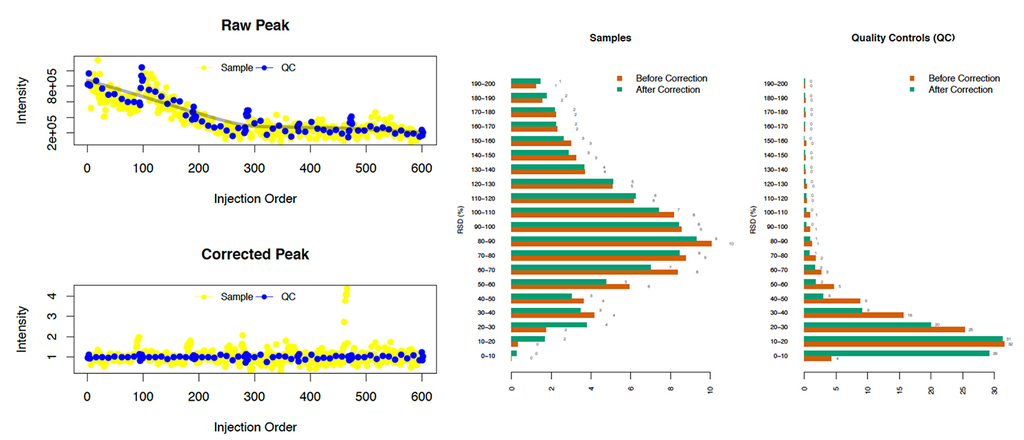

- **The status log (Example data):**

```
**Data File Checking Start..., Time:  Fri Sep 16 14:34:15 2016 **

172 Pheno Samples x172 Profile samples

The Pheno samples list (*NA, missing data from the Profile File)

  [1] "batch01_QC01" "batch01_QC02" "batch01_QC03" "batch01_C05"  "batch01_S07"
  [6] "batch01_C10"  ...

Pheno information:
  Class No.
1     1  66
2     2  68
3    QC  38
  Batch No.
1     1  91
2     2  17
3     3  20
4     4  44

Profile information:
               No.
QC and samples 172
Metabolites     48

**statTarget: shiftCor start...Time:  Fri Sep 16 14:34:15 2016 **

**Step 1: Evaluation of missing value...**

The number of NA value in Data Profile before QC-RLSC: 336

The number of vaiables including 80 % of missing value : 0

**Step 2: Imputation start...**

The number of NA value in Data Profile after the initial imputation: 0

Imputation Finished!

**Step 3: QC-RLSC Start... Time:  Fri Sep 16 14:34:15 2016**
```

[output cut: 38 more lines]

```
           CV<45%    CV<50%    CV<55%    CV<60% CV<65% CV<70% CV<75% CV<80%
Batch_1 100.00000 100.00000 100.00000 100.00000    100    100    100    100
Batch_2  95.83333  97.91667  97.91667  97.91667    100    100    100    100
Batch_3  97.91667  97.91667  97.91667 100.00000    100    100    100    100
Batch_4 100.00000 100.00000 100.00000 100.00000    100    100    100    100
Total   100.00000 100.00000 100.00000 100.00000    100    100    100    100
        CV<85% CV<90% CV<95% CV<100%
Batch_1    100    100    100     100
Batch_2    100    100    100     100
Batch_3    100    100    100     100
Batch_4    100    100    100     100
Total      100    100    100     100


**Correction Finished! Time:  Fri Sep 16 14:34:22 2016**
```

## 3.2 Results of statistic analysis (statAnalysis)

- **The output file:**

  ```
  statTarget -- statAnalysis
  -- PCA_Data_Pareto # Principal Component Analysis
  -- PLS_DA_Pareto # Partial least squares Discriminant Analysis
  -- Univariate# The RSD analysis
     ----- BoxPlot
     ----- Fold_Changes
     ----- Mann-Whitney_Tests # For non-normally distributed variables
     ----- oddratio # odd ratio
     ----- Pvalues # Intergation pvalues from Welch_test and MWT_test
     ----- RForest # Random Forest
     ----- ROC # receiver operating characteristic curve
     ----- Shapiro_Tests
     ----- Significant_Variables
     ----- Volcano_Plots
     ----- WelchTest  # For normally distributed variables
  ```

- **The Figures:**

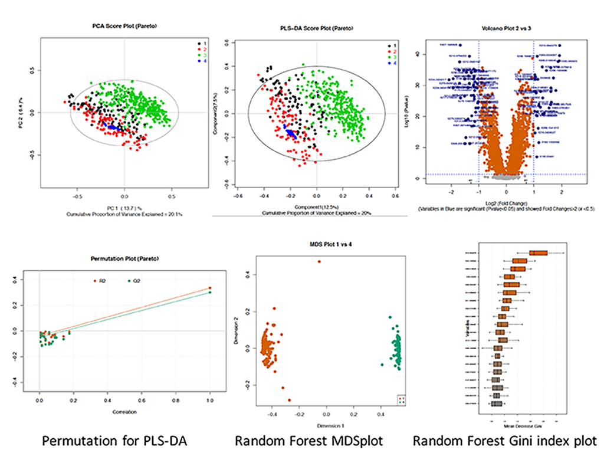

- **The status log (Example data):**

```
**statTarget: statistical analysis start... Time:  Fri Sep 16 14:30:18 2016**

**Step 1: Evaluation of missing value...**

The number of NA value in Data Profile: 1

The number of vaiables including 80 % of missing value : 0

**Step 2: Imputation start... Time:  Fri Sep 16 14:30:18 2016**

The number of NA value in Data Profile after the initialimputation: 1

The number of NA value in Data Profile afterthe second imputation (KNN): 0

Imputation Finished!

**Step 3: Statistic Summary Start... Time:  Fri Sep 16 14:30:18 2016**

**Step 4: Glog PCA-PLSDA start... Time:  Fri Sep 16 14:30:18 2016**

PCA Model Summary

19 samples x 6 variables

Variance Explained of PCA Model:
                             PC1       PC2       PC3       PC4       PC5
Standard deviation     0.4352913 0.2547516 0.1869007 0.1289274 0.0177842
Proportion of Variance 0.6187100 0.2119200 0.1140600 0.0542800 0.0010300
Cumulative Proportion  0.6187100 0.8306300 0.9446900 0.9989700 1.0000000
                                PC6
Standard deviation     1.115663e-15
Proportion of Variance 0.000000e+00
Cumulative Proportion  1.000000e+00

The following observations are calculated as outliers:
[1] "No outliers were detected"

PLS(-DA) Two Component Model Summary

19 samples x 6 variables
```

[output cut: 14 more lines]

```
*P-value was adjusted using Benjamini-Hochberg Method

Odd.Ratio Calculating...

ROC Calculating...

*Group.1 Vs. Group.2

RandomForest Calculating...

*Group.1 Vs. Group.2

Volcano Plot and Box Plot Output...

**Statistical Analysis Finished! Time: Fri Sep 16 14:30:20 2016**
```

# 5 References

Dunn, W.B., et al.,Procedures for large-scale metabolic profiling of serum and plasma using gas chromatography and liquid chromatography coupled to mass spectrometry. Nature Protocols 2011, 6, 1060.

Luan H., LC-MS-Based Urinary Metabolite Signatures in Idiopathic Parkinson’s Disease. J Proteome Res., 2015, 14,467.

Luan H., Non-targeted metabolomics and lipidomics LC-MS data from maternal plasma of 180 healthy pregnant women. GigaScience 2015 4:16